# Линейная регрессия

### Что за регрессия такая?

Одной из задач машинного обучения является задача регрессии. В задачи регрессии мы хотим предсказать переменную $Y$, которая может принимать вещественные значения $Y \in \mathbb{R}$.

Примеры задачи регрессии:

- Сколько денег заработает магазин в следующем месяце?
- Какая завтра будет температура?
- Сколько человеку лет на фото?

Хорошо, с регрессией разобрались, а почему линейная? Все просто! Потому что над всеми признаками применяется обычное линейное преобразование (сумма).

Так выглядит наша модель

$$y_i = w_0 \cdot 1 + w_1 \cdot x_i^{(1)} + w_2 \cdot x_i^{(2)} + \ldots + w_k \cdot x_i^{(k)} + \epsilon_i= w^T \cdot X + \epsilon_i$$
Мы пытаемся ее оценить. После того как мы получили оцененные веса ($\hat{w_i}$), мы можем написать нашу оцененную модель:

$$\hat{y_i} = \hat{w_0} \cdot 1 + \hat{w_1} \cdot x_i^{(1)} + \hat{w_2} \cdot x_i^{(2)} + \ldots + \hat{w_k} \cdot x_i^{(k)} = \hat{w}^T \cdot X$$

### Обучение: придумываем качественные функционалы

Итак, модель построили, осталось обучить. Как было сказано в тетрадке до этого (смотреть [тут](https://ahmedushka7.github.io/R/scripts/hse_data_analysis/sem_linreg/models_intro.html)) для этого надо функционал выбрать, а затем его оптимизировать по весам $w$ так, чтобы он оказался как можно меньше. Ну окей, давайте подберем:

**Делай раз:**

Логично, что наша ошибка это разность между реальным значением $y$ и предсказанным нами *по всем наблюдениям*, то есть для конкретного наблюдения $i$ выглядит это так:

$$y_i - (\hat{w_0} \cdot 1 + \hat{w_1} \cdot x_i^{(1)} + \hat{w_2} \cdot x_i^{(2)} + \ldots + \hat{w_k} \cdot x_i^{(k)}) = y_i - \hat{y_i}$$
А как же нам тогда ошибку по всем наблюдениям посчитать, чтоб получилось одно число?

**Делай два:**

`Идея №1:`

Так давайте просто ошибки по всем наблюдениям сложим и дело с концом. А чтобы мы прославились совсем крутыми математиками, давайте покажем что мы не только складывать умеем, но еще на кол-во делить, чтоб среднее найти:

$$error = \frac{1}{n}\sum_{i=1}^{n}(y_i - \hat{y_i})$$
Но не все так просто….

Такая функция потерь не очень хороша. Представьте, что на 25 наблюдениях у вас ошибка 10, а на остальных 25 ошибка равна -10. В итоге функция потерь будет равна 0, что означает, что модель идеальна и не допускает ошибок. Положительные и отрицательные ошибки “схлопнули” друг друга.

`Идея №2:`

Хмм… Тогда давайте подумаем как такие штуки нам мониторить. Придумали! Будем брать модуль или квадрат ошибки. Ну и так как это наши детища, дадим им названия: в первом случае **MAE – mean absolute error**, а во втором случае **MSE – mean squared error**.

$$MAE = \frac{1}{n} \sum_{i=1}^{n} |y_i - \hat{y_i}|$$
$$MSE = \frac{1}{n} \sum_{i=1}^{n} (y_i -\hat{y_i})^2$$

### Обучение: оптимизация функционалов

Функционал выбрали, осталось его оптимизировать. Будем это делать с помощью метода **градиентного спуска**! Для этого вспомним математический анализ, но обещаю, что его будет совсем немного.

Итак, если у нас есть функция, которая зависит от нескольких параметров, то по каждому параметру мы можем взять производную. Вектор из таких производных называется **градиентом**. У градиента есть очень важное свойство: он указывает в направлении **наискорейшего роста функции**!

$$\nabla f(x_1, \ldots ,x_k) = \Bigl(\frac{\partial{f(x)}}{\partial{x_j}}\Bigr)_{j=1}^k$$
Если мы выбираем в качестве функционала $MSE$, то наш градиент будет выглядеть так:

$$\nabla MSE(w) = \Bigl( \frac{\partial{MSE(w)}}{\partial{w_0}}, \frac{\partial{MSE(w)}}{\partial{w_1}}, \ldots , \frac{\partial{MSE(w)}}{\partial{w_k}} \Bigr )$$

Так как мы *минимизируем* функционал, то нам нужно двигаться не в направлении роста функции, а, наоборот, в направлении убывания. Следовательно, мы будем идти не в сторону градиента, а в направлении **антиградиента**.

Встречайте, градиентный спуск:

1. Присваиваем $w$ рандомные значения (например, нули)
   $$w_0 = w_1 = \ldots = w_k = 0$$
2. Считаем градиент по ним
   $$\nabla MSE(w) = \Bigl( \frac{\partial{MSE(w)}}{\partial{w_0}}|_{w_0 = 0}, \frac{\partial{MSE(w)}}{\partial{w_1}}|_{w_1 = 0}, \ldots , \frac{\partial{MSE(w)}}{\partial{w_k}}|_{w_k = 0} \Bigr )$$
3. Обновляем $w$, вычитая из них значение градиента (еще раз: вычитаем, потому что двигаемся в сторону **антиградиента**, так как мы минимизируем функцию!). Причем вычитать будем не просто значение градиента, а помноженное его на **скорость обучения** $\eta$. Обычно она равна $0.001$, то есть довольна маленькая.

$$w^{t} = w^{t-1} - \eta_t \cdot \nabla MSE(w^{t-1})$$

4. Повторяем все тоже самое, пока веса сильно уменьшаются. $\epsilon$ - очень маленькое число; как только наши веса уменьшаются меньше, чем это число, мы останавливаем процедуру градиентного спуска.

$$||{w^{t} - w^{t-1}}|| > \varepsilon$$

**Простой пример:**

$$y = x^2$$
$$\nabla y = (\frac{\partial{y}}{\partial{x}}) = 2 x$$

*Шаг градиентного спуска №1:*

$$x^{0} = 1$$
$$\nabla y(x^{0}) = 2 \cdot 1 = 2$$
$$x^{1} = x^{0} - \eta \cdot \nabla y(x^{0}) = 1 - 0.01 \cdot 2 = 0.98$$

Возьмем $\epsilon = 0.0000001$. Тогда:

$$||1 - 0.98|| = 0.02 > 0.0000001 \Rightarrow continue$$
Шаг градиентного спуска №2:

$$x^{1} = 0.98$$
$$\nabla y(x^{1}) = 2 \cdot 0.98 = 1.96$$
$$x^{2} = x^{1} - \eta \cdot \nabla y(x^{1}) = 0.98 - 0.01 \cdot 1.96 = 0.9604$$

$$||0.98 - 0.9604|| = 0.0196 > 0.0000001 \Rightarrow continue$$
……

Проделывая так очень много раз в итоге сойдемся к $x = 0$, что и является минимум для функции $y=x^2$.

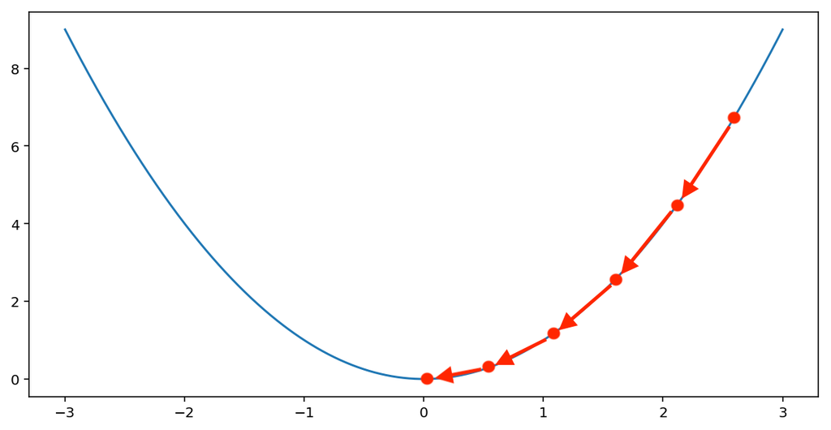

**Замечание:** Сходимость к оптимуму сильно зависит от выбранной скорости обучения. В данном случае мы видим, что ползти мы будем очень медленно. Однако, если мы бы выбрали, например, 1 в качестве значения $\eta$, то тогда на первом шаге уже мы бы перепрыгнули 0 и значение $x$ было бы -1.

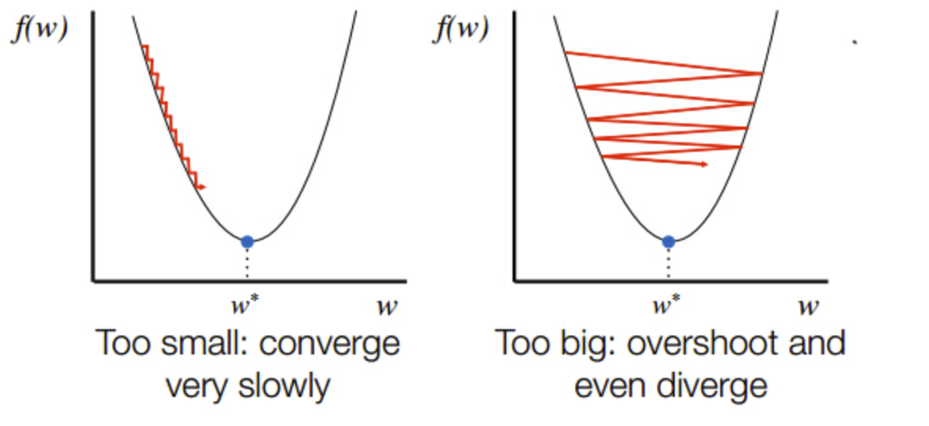

### Категориальные переменные в модели

#### 1. Label encoding

Представим, что в нашей моделе есть признак, который принимает несколько факторных значений. Например, в выборке по студентам есть переменная, отвечающая за то, какой университет закончил студент, и она принимает только 3 значения: РАНХиГС, ВШЭ, МГУ. Так как наша модель понимает только числа, надо эти признаки закодировать. Давайте закодируем их в 1, 2, 3.

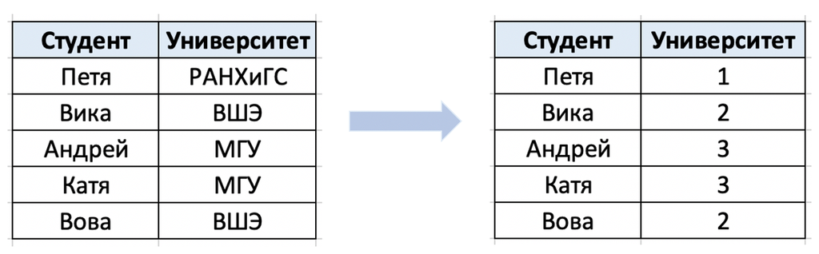

Но тут есть проблема. В таком случае на данных установится некий **порядок**. Модель будет понимать, будто бы раз 2 < 3, значит и категория под номером 2 “меньше” категории под номером 3, то есть ВШЭ хуже МГУ…

[figure not shown]

Чтобы такого избежать, нужно пользоваться **One Hot Encoding**.

#### 2. One Hot Encoding

One Hot Encoding - это преобразование значений категориального признака в отдельные бинарные признаки. То есть раз у нас был признак “Университет”, принимающий значения РАНХиГС, ВШЭ, МГУ, то теперь у нас есть 3 признака РАНХиГС, ВШЭ, МГУ, которые для каждого наблюдения принимают значения 1, если студент закончил данный университет и значения 0, если нет.

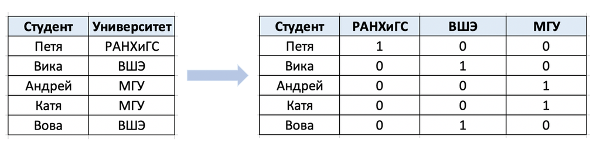

#### 3. Ловушка дамми-переменных

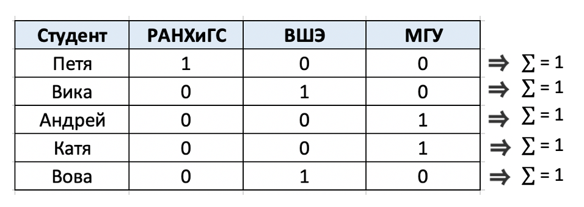

Заметим очень важный момент. После преобразования One Hot Encoding у нас во всех наблюдениях построчная сумма значений в признаках РАНХиГС, ВШЭ и МГУ равна 1. Значит, наши признаки **линейно-зависимы**. Это нарушает одну из предпосылок модели линейной регрессии, обсуждение которых выходит за рамки данного курса, поэтому здесь поступают двумя способами: либо одну категорию выкидывают либо убирают константу из модели.

[figure not shown]